# OnlineNews-Copy1

## Group 3 for MSDS 7331 Lab One: Visualization and Data Preprocessing

*Analysis of Online News Popularity Dataset (https://archive.ics.uci.edu/ml/datasets/Online+News+Popularity): explore the statistical summaries of the features, visualize the attributes, and make conclusions from the visualizations and analysis*

### 01. Business Understanding (10)

- Describe the purpose of the data set you selected (i.e., why was this data collected in the first place?). Describe how you would define and measure the outcomes from the dataset. That is, why is this data important and how do you know if you have mined useful knowledge from the dataset? How would you measure the effectiveness of a good prediction algorithm? Be specific *

This Online News Popularity Dataset was acquisited from Mashable (https://mashable.com) on 01/08/2015 and the goal is to predict the number of shares in social networks (popularity).

**Attribute Information:**

### 02. Data Mining Type (10)

- Describe the meaning and type of data (scale, values, etc.) for each attribute in the data file.

  Number of Attributes: 61 (58 predictive attributes, 2 non-predictive, 1 goal field)
- url: URL of the article (non-predictive)
- timedelta: Days between the article publication and the dataset acquisition (non-predictive)
- n_tokens_title: Number of words in the title
- n_tokens_content: Number of words in the content
- n_unique_tokens: Rate of unique words in the content
- n_non_stop_words: Rate of non-stop words in the content
- n_non_stop_unique_tokens: Rate of unique non-stop words in the content
- num_hrefs: Number of links
- num_self_hrefs: Number of links to other articles published by Mashable
- num_imgs: Number of images
- num_videos: Number of videos
- average_token_length: Average length of the words in the content
- num_keywords: Number of keywords in the metadata
- data_channel_is_lifestyle: Is data channel 'Lifestyle'?
- data_channel_is_entertainment: Is data channel 'Entertainment'?
- data_channel_is_bus: Is data channel 'Business'?
- data_channel_is_socmed: Is data channel 'Social Media'?
- data_channel_is_tech: Is data channel 'Tech'?
- data_channel_is_world: Is data channel 'World'?
- kw_min_min: Worst keyword (min. shares)
- kw_max_min: Worst keyword (max. shares)
- kw_avg_min: Worst keyword (avg. shares)
- kw_min_max: Best keyword (min. shares)
- kw_max_max: Best keyword (max. shares)
- kw_avg_max: Best keyword (avg. shares)
- kw_min_avg: Avg. keyword (min. shares)
- kw_max_avg: Avg. keyword (max. shares)
- kw_avg_avg: Avg. keyword (avg. shares)
- self_reference_min_shares: Min. shares of referenced articles in Mashable
- self_reference_max_shares: Max. shares of referenced articles in Mashable
- self_reference_avg_sharess: Avg. shares of referenced articles in Mashable
- weekday_is_monday: Was the article published on a Monday?
- weekday_is_tuesday: Was the article published on a Tuesday?
- weekday_is_wednesday: Was the article published on a Wednesday?
- weekday_is_thursday: Was the article published on a Thursday?
- weekday_is_friday: Was the article published on a Friday?
- weekday_is_saturday: Was the article published on a Saturday?
- weekday_is_sunday: Was the article published on a Sunday?
- is_weekend: Was the article published on the weekend?
- LDA_00: Closeness to LDA topic 0
- LDA_01: Closeness to LDA topic 1
- LDA_02: Closeness to LDA topic 2
- LDA_03: Closeness to LDA topic 3
- LDA_04: Closeness to LDA topic 4
- global_subjectivity: Text subjectivity
- global_sentiment_polarity: Text sentiment polarity
- global_rate_positive_words: Rate of positive words in the content
- global_rate_negative_words: Rate of negative words in the content
- rate_positive_words: Rate of positive words among non-neutral tokens
- rate_negative_words: Rate of negative words among non-neutral tokens
- avg_positive_polarity: Avg. polarity of positive words
- min_positive_polarity: Min. polarity of positive words
- max_positive_polarity: Max. polarity of positive words
- avg_negative_polarity: Avg. polarity of negative words
- min_negative_polarity: Min. polarity of negative words
- max_negative_polarity: Max. polarity of negative words
- title_subjectivity: Title subjectivity
- title_sentiment_polarity: Title polarity
- abs_title_subjectivity: Absolute subjectivity level
- abs_title_sentiment_polarity: Absolute polarity level
- shares: Number of shares (target) *

### 03. Data Quality (15)

- Verify data quality: Explain any missing values, duplicate data, and outliers. Are those mistakes? How do you deal with these problems? Give justifications for your methods. *

```python
# Import libraries usef for this Lab1 project
import pandas as pd
import numpy as np
import matplotlib.pyplot as plt
import seaborn as sns
%matplotlib inline
```

```python
# Read csv file
df = pd.read_csv('/Users/shanqinggu/Desktop/OnlineNewsPopularity.csv')
df.info()
```

```
<class 'pandas.core.frame.DataFrame'>
RangeIndex: 39644 entries, 0 to 39643
Data columns (total 61 columns):
url                               39644 non-null object
 timedelta                        39644 non-null float64
 n_tokens_title                   39644 non-null float64
 n_tokens_content                 39644 non-null float64
 n_unique_tokens                  39644 non-null float64
 n_non_stop_words                 39644 non-null float64
 n_non_stop_unique_tokens         39644 non-null float64
 num_hrefs                        39644 non-null float64
 num_self_hrefs                   39644 non-null float64
 num_imgs                         39644 non-null float64
 num_videos                       39644 non-null float64
 average_token_length             39644 non-null float64
 num_keywords                     39644 non-null float64
 data_channel_is_lifestyle        39644 non-null float64
 data_channel_is_entertainment    39644 non-null float64
 data_channel_is_bus              39644 non-null float64
 data_channel_is_socmed           39644 non-null float64
 data_channel_is_tech             39644 non-null float64
 data_channel_is_world            39644 non-null float64
 kw_min_min                       39644 non-null float64
 kw_max_min                       39644 non-null float64
 kw_avg_min                       39644 non-null float64
 kw_min_max                       39644 non-null float64
 kw_max_max                       39644 non-null float64
 kw_avg_max                       39644 non-null float64
 kw_min_avg                       39644 non-null float64
 kw_max_avg                       39644 non-null float64
 kw_avg_avg                       39644 non-null float64
 self_reference_min_shares        39644 non-null float64
 self_reference_max_shares        39644 non-null float64
 self_reference_avg_sharess       39644 non-null float64
 weekday_is_monday                39644 non-null float64
 weekday_is_tuesday               39644 non-null float64
 weekday_is_wednesday             39644 non-null float64
 weekday_is_thursday              39644 non-null float64
 weekday_is_friday                39644 non-null float64
 weekday_is_saturday              39644 non-null float64
```

[output cut: 11 more lines]

```
 rate_positive_words              39644 non-null float64
 rate_negative_words              39644 non-null float64
 avg_positive_polarity            39644 non-null float64
 min_positive_polarity            39644 non-null float64
 max_positive_polarity            39644 non-null float64
 avg_negative_polarity            39644 non-null float64
 min_negative_polarity            39644 non-null float64
 max_negative_polarity            39644 non-null float64
 title_subjectivity               39644 non-null float64
 title_sentiment_polarity         39644 non-null float64
 abs_title_subjectivity           39644 non-null float64
 abs_title_sentiment_polarity     39644 non-null float64
 shares                           39644 non-null int64
dtypes: float64(59), int64(1), object(1)
memory usage: 18.5+ MB
```

```python
# Exclude url and view the data from the top row of the frame
df = df.loc[:, ' n_tokens_title':]
df.head() # use df.tail() to read from the bottom
```

|  | n_tokens_title | n_tokens_content | n_unique_tokens | n_non_stop_words | n_non_stop_unique_tokens | num_hrefs | num_self_hrefs | num_imgs | num_videos | average_token_length | ... | min_positive_polarity | max_positive_polarity | avg_negative_polarity | min_negative_polarity | max_negative_polarity | title_subjectivity | title_sentiment_polarity | abs_title_subjectivity | abs_title_sentiment_polarity | shares |
| --- | --- | --- | --- | --- | --- | --- | --- | --- | --- | --- | --- | --- | --- | --- | --- | --- | --- | --- | --- | --- | --- |
| 0 | 12.0 | 219.0 | 0.663594 | 1.0 | 0.815385 | 4.0 | 2.0 | 1.0 | 0.0 | 4.680365 | ... | 0.100000 | 0.7 | -0.350000 | -0.600 | -0.200000 | 0.500000 | -0.187500 | 0.000000 | 0.187500 | 593 |
| 1 | 9.0 | 255.0 | 0.604743 | 1.0 | 0.791946 | 3.0 | 1.0 | 1.0 | 0.0 | 4.913725 | ... | 0.033333 | 0.7 | -0.118750 | -0.125 | -0.100000 | 0.000000 | 0.000000 | 0.500000 | 0.000000 | 711 |
| 2 | 9.0 | 211.0 | 0.575130 | 1.0 | 0.663866 | 3.0 | 1.0 | 1.0 | 0.0 | 4.393365 | ... | 0.100000 | 1.0 | -0.466667 | -0.800 | -0.133333 | 0.000000 | 0.000000 | 0.500000 | 0.000000 | 1500 |
| 3 | 9.0 | 531.0 | 0.503788 | 1.0 | 0.665635 | 9.0 | 0.0 | 1.0 | 0.0 | 4.404896 | ... | 0.136364 | 0.8 | -0.369697 | -0.600 | -0.166667 | 0.000000 | 0.000000 | 0.500000 | 0.000000 | 1200 |
| 4 | 13.0 | 1072.0 | 0.415646 | 1.0 | 0.540890 | 19.0 | 19.0 | 20.0 | 0.0 | 4.682836 | ... | 0.033333 | 1.0 | -0.220192 | -0.500 | -0.050000 | 0.454545 | 0.136364 | 0.045455 | 0.136364 | 505 |

5 rows × 59 columns

```python
df.dtypes
```

```
 n_tokens_title                   float64
 n_tokens_content                 float64
 n_unique_tokens                  float64
 n_non_stop_words                 float64
 n_non_stop_unique_tokens         float64
 num_hrefs                        float64
 num_self_hrefs                   float64
 num_imgs                         float64
 num_videos                       float64
 average_token_length             float64
 num_keywords                     float64
 data_channel_is_lifestyle        float64
 data_channel_is_entertainment    float64
 data_channel_is_bus              float64
 data_channel_is_socmed           float64
 data_channel_is_tech             float64
 data_channel_is_world            float64
 kw_min_min                       float64
 kw_max_min                       float64
 kw_avg_min                       float64
 kw_min_max                       float64
 kw_max_max                       float64
 kw_avg_max                       float64
 kw_min_avg                       float64
 kw_max_avg                       float64
 kw_avg_avg                       float64
 self_reference_min_shares        float64
 self_reference_max_shares        float64
 self_reference_avg_sharess       float64
 weekday_is_monday                float64
 weekday_is_tuesday               float64
 weekday_is_wednesday             float64
 weekday_is_thursday              float64
 weekday_is_friday                float64
 weekday_is_saturday              float64
 weekday_is_sunday                float64
 is_weekend                       float64
 LDA_00                           float64
 LDA_01                           float64
 LDA_02                           float64
 LDA_03                           float64
 LDA_04                           float64
 global_subjectivity              float64
 global_sentiment_polarity        float64
 global_rate_positive_words       float64
 global_rate_negative_words       float64
 rate_positive_words              float64
 rate_negative_words              float64
 avg_positive_polarity            float64
 min_positive_polarity            float64
 max_positive_polarity            float64
 avg_negative_polarity            float64
 min_negative_polarity            float64
 max_negative_polarity            float64
 title_subjectivity               float64
 title_sentiment_polarity         float64
 abs_title_subjectivity           float64
 abs_title_sentiment_polarity     float64
 shares                             int64
dtype: object
```

```python
# Make new column Channel for lifestyle, entertainment, bus, socmed, tech and world

Lifestyle_df=df[df[' data_channel_is_lifestyle']==1]
Lifestyle_df[' Channel']='Lifestyle'

Entertainment_df=df[df[' data_channel_is_entertainment']==1]
Entertainment_df[' Channel']='Entertainment'

Bus_df=df[df[' data_channel_is_bus']==1]
Bus_df[' Channel']='Bus'

Socmed_df=df[df[' data_channel_is_socmed']==1]
Socmed_df[' Channel']='Socmedia'

Tech_df=df[df[' data_channel_is_tech']==1]
Tech_df[' Channel']='Tech'

World_df=df[df[' data_channel_is_world']==1]
World_df[' Channel']='World'

df=pd.concat([Lifestyle_df,Entertainment_df,Bus_df,Socmed_df,Tech_df,World_df],axis=0)
```

[output not shown]

```python
# make new column weekday for Monday, Tuesday, Wednesday, Thursday, Friday, Saturday, Sunday, and Weekend

Monday_df=df[df[' weekday_is_monday']==1]
Monday_df[' weekday']='Monday'

Tuesday_df=df[df[' weekday_is_tuesday']==1]
Tuesday_df[' weekday']='Tuesday'

Wednesday_df=df[df[' weekday_is_wednesday']==1]
Wednesday_df[' weekday']='Wednesday'

Thursday_df=df[df[' weekday_is_thursday']==1]
Thursday_df[' weekday']='Thursday'

Friday_df=df[df[' weekday_is_friday']==1]
Friday_df[' weekday']='Friday'

Saturday_df=df[df[' weekday_is_saturday']==1]
Saturday_df[' weekday']='Saturday'

Sunday_df=df[df[' weekday_is_sunday']==1]
Sunday_df[' weekday']='Sunday'

df=pd.concat([Monday_df,Tuesday_df,Wednesday_df,Thursday_df,Friday_df,Saturday_df,Sunday_df],axis=0)
```

[output not shown]

```python
# Check data types
df.dtypes
```

```
 n_tokens_title                   float64
 n_tokens_content                 float64
 n_unique_tokens                  float64
 n_non_stop_words                 float64
 n_non_stop_unique_tokens         float64
 num_hrefs                        float64
 num_self_hrefs                   float64
 num_imgs                         float64
 num_videos                       float64
 average_token_length             float64
 num_keywords                     float64
 data_channel_is_lifestyle        float64
 data_channel_is_entertainment    float64
 data_channel_is_bus              float64
 data_channel_is_socmed           float64
 data_channel_is_tech             float64
 data_channel_is_world            float64
 kw_min_min                       float64
 kw_max_min                       float64
 kw_avg_min                       float64
 kw_min_max                       float64
 kw_max_max                       float64
 kw_avg_max                       float64
 kw_min_avg                       float64
 kw_max_avg                       float64
 kw_avg_avg                       float64
 self_reference_min_shares        float64
 self_reference_max_shares        float64
 self_reference_avg_sharess       float64
 weekday_is_monday                float64
                                   ...
 weekday_is_wednesday             float64
 weekday_is_thursday              float64
 weekday_is_friday                float64
 weekday_is_saturday              float64
 weekday_is_sunday                float64
 is_weekend                       float64
 LDA_00                           float64
 LDA_01                           float64
 LDA_02                           float64
 LDA_03                           float64
 LDA_04                           float64
 global_subjectivity              float64
 global_sentiment_polarity        float64
 global_rate_positive_words       float64
 global_rate_negative_words       float64
 rate_positive_words              float64
 rate_negative_words              float64
 avg_positive_polarity            float64
 min_positive_polarity            float64
 max_positive_polarity            float64
 avg_negative_polarity            float64
 min_negative_polarity            float64
 max_negative_polarity            float64
 title_subjectivity               float64
 title_sentiment_polarity         float64
 abs_title_subjectivity           float64
 abs_title_sentiment_polarity     float64
 shares                             int64
 Channel                           object
 weekday                           object
Length: 61, dtype: object
```

```python
# Check data shape

df.shape
```

```
(33510, 61)
```

```python
# Display the index
df.index
```

```
Int64Index([    6,    11,    18,    28,    34,    35,    46,    75,   362,
              363,
            ...
            39492, 39497, 39498, 39499, 39501, 39504, 39505, 39508, 39515,
            39516],
           dtype='int64', length=33510)
```

```python
# Display the columns
df.columns
```

```
Index([' n_tokens_title', ' n_tokens_content', ' n_unique_tokens',
       ' n_non_stop_words', ' n_non_stop_unique_tokens', ' num_hrefs',
       ' num_self_hrefs', ' num_imgs', ' num_videos', ' average_token_length',
       ' num_keywords', ' data_channel_is_lifestyle',
       ' data_channel_is_entertainment', ' data_channel_is_bus',
       ' data_channel_is_socmed', ' data_channel_is_tech',
       ' data_channel_is_world', ' kw_min_min', ' kw_max_min', ' kw_avg_min',
       ' kw_min_max', ' kw_max_max', ' kw_avg_max', ' kw_min_avg',
       ' kw_max_avg', ' kw_avg_avg', ' self_reference_min_shares',
       ' self_reference_max_shares', ' self_reference_avg_sharess',
       ' weekday_is_monday', ' weekday_is_tuesday', ' weekday_is_wednesday',
       ' weekday_is_thursday', ' weekday_is_friday', ' weekday_is_saturday',
       ' weekday_is_sunday', ' is_weekend', ' LDA_00', ' LDA_01', ' LDA_02',
       ' LDA_03', ' LDA_04', ' global_subjectivity',
       ' global_sentiment_polarity', ' global_rate_positive_words',
       ' global_rate_negative_words', ' rate_positive_words',
       ' rate_negative_words', ' avg_positive_polarity',
       ' min_positive_polarity', ' max_positive_polarity',
       ' avg_negative_polarity', ' min_negative_polarity',
       ' max_negative_polarity', ' title_subjectivity',
       ' title_sentiment_polarity', ' abs_title_subjectivity',
       ' abs_title_sentiment_polarity', ' shares', ' Channel', ' weekday'],
      dtype='object')
```

```python
# Display the underlying numpy data
df.values
```

```
array([[8.0, 960.0, 0.418162618355, ..., 556, 'Lifestyle', 'Monday'],
       [10.0, 187.0, 0.6666666630820001, ..., 1900, 'Lifestyle',
        'Monday'],
       [11.0, 103.0, 0.689320381657, ..., 5700, 'Lifestyle', 'Monday'],
       ...,
       [12.0, 496.0, 0.521367520253, ..., 1300, 'World', 'Sunday'],
       [7.0, 0.0, 0.0, ..., 1600, 'World', 'Sunday'],
       [13.0, 936.0, 0.42622950773100005, ..., 2000, 'World', 'Sunday']],
      dtype=object)
```

```python
# No Missing values in this dataset
pd.isnull(df).sum()
```

```
 n_tokens_title                   0
 n_tokens_content                 0
 n_unique_tokens                  0
 n_non_stop_words                 0
 n_non_stop_unique_tokens         0
 num_hrefs                        0
 num_self_hrefs                   0
 num_imgs                         0
 num_videos                       0
 average_token_length             0
 num_keywords                     0
 data_channel_is_lifestyle        0
 data_channel_is_entertainment    0
 data_channel_is_bus              0
 data_channel_is_socmed           0
 data_channel_is_tech             0
 data_channel_is_world            0
 kw_min_min                       0
 kw_max_min                       0
 kw_avg_min                       0
 kw_min_max                       0
 kw_max_max                       0
 kw_avg_max                       0
 kw_min_avg                       0
 kw_max_avg                       0
 kw_avg_avg                       0
 self_reference_min_shares        0
 self_reference_max_shares        0
 self_reference_avg_sharess       0
 weekday_is_monday                0
                                 ..
 weekday_is_wednesday             0
 weekday_is_thursday              0
 weekday_is_friday                0
 weekday_is_saturday              0
 weekday_is_sunday                0
 is_weekend                       0
 LDA_00                           0
 LDA_01                           0
 LDA_02                           0
 LDA_03                           0
 LDA_04                           0
 global_subjectivity              0
 global_sentiment_polarity        0
 global_rate_positive_words       0
 global_rate_negative_words       0
 rate_positive_words              0
 rate_negative_words              0
 avg_positive_polarity            0
 min_positive_polarity            0
 max_positive_polarity            0
 avg_negative_polarity            0
 min_negative_polarity            0
 max_negative_polarity            0
 title_subjectivity               0
 title_sentiment_polarity         0
 abs_title_subjectivity           0
 abs_title_sentiment_polarity     0
 shares                           0
 Channel                          0
 weekday                          0
Length: 61, dtype: int64
```

```python
# No duplicated values in this dataset

df[df.duplicated(keep=False)]
```

|  | n_tokens_title | n_tokens_content | n_unique_tokens | n_non_stop_words | n_non_stop_unique_tokens | num_hrefs | num_self_hrefs | num_imgs | num_videos | average_token_length | ... | avg_negative_polarity | min_negative_polarity | max_negative_polarity | title_subjectivity | title_sentiment_polarity | abs_title_subjectivity | abs_title_sentiment_polarity | shares | Channel | weekday |
| --- | --- | --- | --- | --- | --- | --- | --- | --- | --- | --- | --- | --- | --- | --- | --- | --- | --- | --- | --- | --- | --- |

0 rows × 61 columns

```python
# Check outliers
```

[output not shown]

### 04. Simple Statistics (10)

- Visualize appropriate statistics (e.g., range, mode, mean, median, variance, counts) for a subset of attributes. Describe anything meaningful you found from this or if you found something potentially interesting. Note: You can also use data from other sources for comparison. Explain why the statistics run are meaningful. *

```python
# Quick statistic summary of the data
df.describe().transpose()
```

|  | count | mean | std | min | 25% | 50% | 75% | max |
| --- | --- | --- | --- | --- | --- | --- | --- | --- |
| n_tokens_title | 33510.0 | 10.416204 | 2.134557 | 2.000000 | 9.000000 | 10.000000 | 12.000000 | 23.000000 |
| n_tokens_content | 33510.0 | 585.438317 | 483.838530 | 0.000000 | 272.000000 | 447.000000 | 761.000000 | 8474.000000 |
| n_unique_tokens | 33510.0 | 0.549702 | 3.828350 | 0.000000 | 0.467396 | 0.532596 | 0.600000 | 701.000000 |
| n_non_stop_words | 33510.0 | 1.015010 | 5.688218 | 0.000000 | 1.000000 | 1.000000 | 1.000000 | 1042.000000 |
| n_non_stop_unique_tokens | 33510.0 | 0.699134 | 3.549460 | 0.000000 | 0.628370 | 0.690411 | 0.752475 | 650.000000 |
| num_hrefs | 33510.0 | 10.380603 | 10.599809 | 0.000000 | 4.000000 | 7.000000 | 13.000000 | 304.000000 |
| num_self_hrefs | 33510.0 | 3.368517 | 3.883522 | 0.000000 | 1.000000 | 3.000000 | 4.000000 | 116.000000 |
| num_imgs | 33510.0 | 3.959445 | 7.725860 | 0.000000 | 1.000000 | 1.000000 | 3.000000 | 128.000000 |
| num_videos | 33510.0 | 0.998448 | 3.651955 | 0.000000 | 0.000000 | 0.000000 | 1.000000 | 75.000000 |
| average_token_length | 33510.0 | 4.607736 | 0.646702 | 0.000000 | 4.490385 | 4.669471 | 4.852841 | 7.695652 |
| num_keywords | 33510.0 | 7.177798 | 1.952422 | 1.000000 | 6.000000 | 7.000000 | 9.000000 | 10.000000 |
| data_channel_is_lifestyle | 33510.0 | 0.062638 | 0.242314 | 0.000000 | 0.000000 | 0.000000 | 0.000000 | 1.000000 |
| data_channel_is_entertainment | 33510.0 | 0.210594 | 0.407736 | 0.000000 | 0.000000 | 0.000000 | 0.000000 | 1.000000 |
| data_channel_is_bus | 33510.0 | 0.186750 | 0.389717 | 0.000000 | 0.000000 | 0.000000 | 0.000000 | 1.000000 |
| data_channel_is_socmed | 33510.0 | 0.069323 | 0.254006 | 0.000000 | 0.000000 | 0.000000 | 0.000000 | 1.000000 |
| data_channel_is_tech | 33510.0 | 0.219218 | 0.413723 | 0.000000 | 0.000000 | 0.000000 | 0.000000 | 1.000000 |
| data_channel_is_world | 33510.0 | 0.251477 | 0.433869 | 0.000000 | 0.000000 | 0.000000 | 1.000000 | 1.000000 |
| kw_min_min | 33510.0 | 25.539421 | 68.985113 | -1.000000 | -1.000000 | -1.000000 | 4.000000 | 377.000000 |
| kw_max_min | 33510.0 | 1114.712389 | 3522.943324 | 0.000000 | 444.000000 | 656.000000 | 1000.000000 | 298400.000000 |
| kw_avg_min | 33510.0 | 309.083875 | 607.002311 | -1.000000 | 141.025000 | 237.316667 | 360.428571 | 42827.857143 |
| kw_min_max | 33510.0 | 12207.393972 | 54698.026221 | 0.000000 | 0.000000 | 1300.000000 | 6800.000000 | 843300.000000 |
| kw_max_max | 33510.0 | 753337.156073 | 213034.725810 | 0.000000 | 843300.000000 | 843300.000000 | 843300.000000 | 843300.000000 |
| kw_avg_max | 33510.0 | 241773.119564 | 122864.851517 | 0.000000 | 165789.285715 | 228286.666666 | 310000.000000 | 843300.000000 |
| kw_min_avg | 33510.0 | 1031.643292 | 1067.121534 | -1.000000 | 0.000000 | 956.466667 | 1936.365694 | 3610.124972 |
| kw_max_avg | 33510.0 | 5161.325150 | 5587.406032 | 0.000000 | 3504.363334 | 4044.559329 | 5346.671878 | 298400.000000 |
| kw_avg_avg | 33510.0 | 2890.423023 | 1126.330419 | 0.000000 | 2312.970075 | 2737.047950 | 3271.472136 | 43567.659946 |
| self_reference_min_shares | 33510.0 | 3565.717849 | 19322.677838 | 0.000000 | 620.000000 | 1100.000000 | 2400.000000 | 690400.000000 |
| self_reference_max_shares | 33510.0 | 9594.667448 | 39921.174733 | 0.000000 | 1000.000000 | 2700.000000 | 7300.000000 | 837700.000000 |
| self_reference_avg_sharess | 33510.0 | 5820.979727 | 23681.940504 | 0.000000 | 957.083333 | 2100.000000 | 4650.000000 | 690400.000000 |
| weekday_is_monday | 33510.0 | 0.171919 | 0.377316 | 0.000000 | 0.000000 | 0.000000 | 0.000000 | 1.000000 |
| weekday_is_tuesday | 33510.0 | 0.187377 | 0.390220 | 0.000000 | 0.000000 | 0.000000 | 0.000000 | 1.000000 |
| weekday_is_wednesday | 33510.0 | 0.189555 | 0.391955 | 0.000000 | 0.000000 | 0.000000 | 0.000000 | 1.000000 |
| weekday_is_thursday | 33510.0 | 0.183975 | 0.387470 | 0.000000 | 0.000000 | 0.000000 | 0.000000 | 1.000000 |
| weekday_is_friday | 33510.0 | 0.141301 | 0.348337 | 0.000000 | 0.000000 | 0.000000 | 0.000000 | 1.000000 |
| weekday_is_saturday | 33510.0 | 0.060549 | 0.238505 | 0.000000 | 0.000000 | 0.000000 | 0.000000 | 1.000000 |
| weekday_is_sunday | 33510.0 | 0.065324 | 0.247100 | 0.000000 | 0.000000 | 0.000000 | 0.000000 | 1.000000 |
| is_weekend | 33510.0 | 0.125873 | 0.331711 | 0.000000 | 0.000000 | 0.000000 | 0.000000 | 1.000000 |
| LDA_00 | 33510.0 | 0.207364 | 0.277868 | 0.000000 | 0.025188 | 0.040000 | 0.320122 | 0.926994 |
| LDA_01 | 33510.0 | 0.141303 | 0.224786 | 0.000000 | 0.025005 | 0.033339 | 0.134308 | 0.925947 |
| LDA_02 | 33510.0 | 0.245294 | 0.295739 | 0.000000 | 0.028573 | 0.050001 | 0.432298 | 0.919999 |
| LDA_03 | 33510.0 | 0.140653 | 0.224266 | 0.000000 | 0.025033 | 0.033373 | 0.136139 | 0.925542 |
| LDA_04 | 33510.0 | 0.265356 | 0.301748 | 0.000000 | 0.029340 | 0.050763 | 0.485458 | 0.927191 |
| global_subjectivity | 33510.0 | 0.439569 | 0.099129 | 0.000000 | 0.393133 | 0.447111 | 0.497383 | 1.000000 |
| global_sentiment_polarity | 33510.0 | 0.119596 | 0.090615 | -0.377657 | 0.062231 | 0.119719 | 0.175602 | 0.727841 |
| global_rate_positive_words | 33510.0 | 0.039891 | 0.016444 | 0.000000 | 0.028889 | 0.039164 | 0.050205 | 0.155488 |
| global_rate_negative_words | 33510.0 | 0.016320 | 0.009943 | 0.000000 | 0.009768 | 0.015209 | 0.021277 | 0.139831 |
| rate_positive_words | 33510.0 | 0.695364 | 0.171064 | 0.000000 | 0.611111 | 0.714286 | 0.800000 | 1.000000 |
| rate_negative_words | 33510.0 | 0.288462 | 0.150604 | 0.000000 | 0.188679 | 0.277778 | 0.379310 | 1.000000 |
| avg_positive_polarity | 33510.0 | 0.351704 | 0.091821 | 0.000000 | 0.305024 | 0.354545 | 0.403922 | 1.000000 |
| min_positive_polarity | 33510.0 | 0.091221 | 0.064398 | 0.000000 | 0.050000 | 0.100000 | 0.100000 | 1.000000 |
| max_positive_polarity | 33510.0 | 0.762561 | 0.231811 | 0.000000 | 0.600000 | 0.800000 | 1.000000 | 1.000000 |
| avg_negative_polarity | 33510.0 | -0.255202 | 0.117386 | -1.000000 | -0.318403 | -0.250000 | -0.186667 | 0.000000 |
| min_negative_polarity | 33510.0 | -0.524040 | 0.283454 | -1.000000 | -0.700000 | -0.500000 | -0.300000 | 0.000000 |
| max_negative_polarity | 33510.0 | -0.104041 | 0.086693 | -1.000000 | -0.125000 | -0.100000 | -0.050000 | 0.000000 |
| title_subjectivity | 33510.0 | 0.265740 | 0.314245 | 0.000000 | 0.000000 | 0.100000 | 0.500000 | 1.000000 |
| title_sentiment_polarity | 33510.0 | 0.068661 | 0.252802 | -1.000000 | 0.000000 | 0.000000 | 0.136364 | 1.000000 |
| abs_title_subjectivity | 33510.0 | 0.343692 | 0.188397 | 0.000000 | 0.166667 | 0.500000 | 0.500000 | 0.500000 |
| abs_title_sentiment_polarity | 33510.0 | 0.145570 | 0.217789 | 0.000000 | 0.000000 | 0.000000 | 0.225000 | 1.000000 |
| shares | 33510.0 | 2928.637989 | 9470.520277 | 1.000000 | 930.000000 | 1400.000000 | 2500.000000 | 690400.000000 |

```
array([[<matplotlib.axes._subplots.AxesSubplot object at 0x1a22b83160>,
      dtype=object)
```

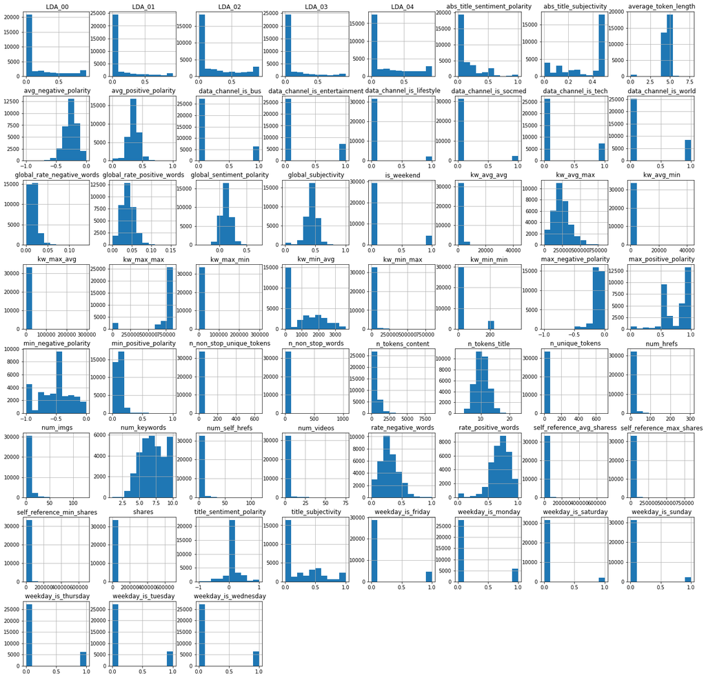

```python
# Check histograms

df.hist(figsize=(24,24))
```

### 05. Visualize Attributes (15)

- Visualize the most interesting attributes (at least 5 attributes, your opinion on what is interesting). Important: Interpret the implications for each visualization. Explain for each attribute why the chosen visualization is appropriate.*

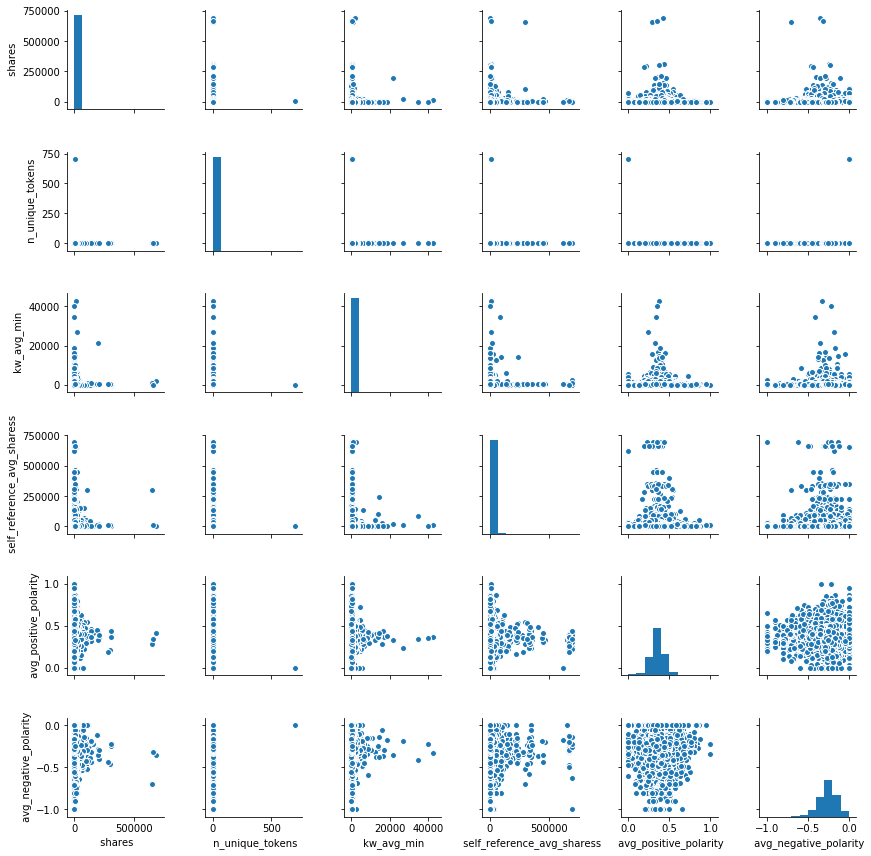

```python
# Prepare data subset for plotting and chooseing related Variables

sns.pairplot(df, vars=[' shares',' n_unique_tokens', ' kw_avg_min',' self_reference_avg_sharess',' avg_positive_polarity',' avg_negative_polarity'], size=2)
```

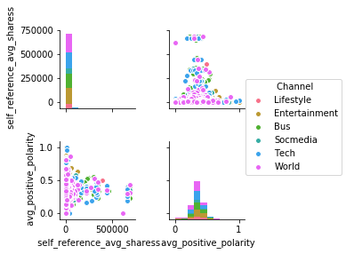

```python
# Pairplot with self_reference_avg_shares and avg_positive_polarity as grouped by Channel

sns.pairplot(df, vars=[' self_reference_avg_sharess',' avg_positive_polarity'], hue=" Channel", palette="husl", size=2)
```

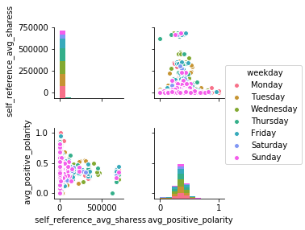

```python
# Pairplot with self_reference_avg_shares and avg_positive_polarity as grouped by weekday

sns.pairplot(df, vars=[' self_reference_avg_sharess',' avg_positive_polarity'], hue=" weekday", palette="husl", size=2)
```

```python
# sns.set(style="white")

# create a plot grid
# g = sns.PairGrid(df[[' shares',' n_unique_tokens']], diag_sharey=False)
# g.map_lower(sns.kdeplot, cmap="Blues_d") # use joint kde on the lower triangle

# Not working
```

```python
## sns.factorplot(x=' shares',y=' n_unique_tokens', data=df,
               kind='violin', # other options: violin, bar, box, and others
               palette='PRGn',
               size=7,ci=95)

## Not working
```

### 06. Explore Joint Attributes (15)

- Visualize relationships between attributes: Look at the attributes via scatter plots, correlation, cross-tabulation, group-wise averages, etc. as appropriate. Explain any interesting relationships.*

```python
## from pandas.plotting import scatter_matrix
## scatter_matrix(df, alpha=0.2, figsize=(12,12), diagonal='kde')

## from pandas.plotting import scatter_matrix

## df_scatter = scatter_matrix(df,figsize=(15, 10))

# Running slow and no results
```

```python
numeric = [c for i,c in enumerate(df.columns) if df.dtypes[i] in [np.float64, np.int64]]
len(numeric)
```

```
59
```

```python
## sns.pairplot(df[numeric[:5]], hue = "is_weekend", size=2)
## running slow and did not get results
```

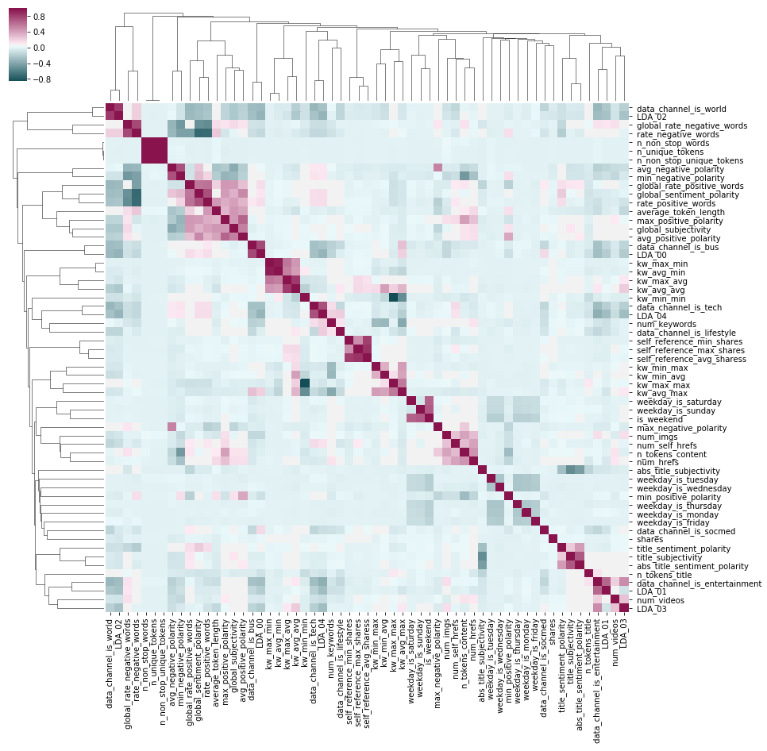

```python
# Correlation

cmap = sns.diverging_palette(h_neg=210, h_pos=350, s=90, l=30, as_cmap=True, center="light")
sns.clustermap(df[numeric].corr(), figsize=(14, 14), cmap=cmap);
```

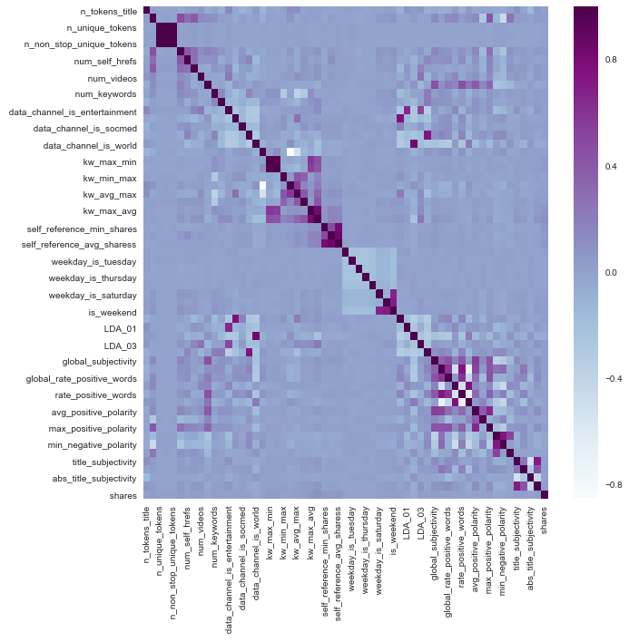

```python
# plot the correlation matrix using seaborn

sns.set(style="darkgrid") # one of the many styles to plot using

df_heatmap = plt.subplots(figsize=(10, 10))

sns.heatmap(df.corr(), cmap="BuPu")
```

### 07. Explore Attributes and Class (10)

- Identify and explain interesting relationships between features and the class you are trying to predict (i.e., relationships with variables and the target classification).*

### 08. New Features (5)

- Are there other features that could be added to the data or created from existing features? Which ones? *

### 09. Exceptional Work (10)

- You have free reign to provide additional analyses. One idea: implement dimensionality reduction, then visualize and interpret the results.*